# isemenov_PML

Ilia Semenov

Saturday, January 30, 2016

## Synopsis

This report is devoted to the analyses of the HAR (Human Activity Recognition) data with the goal of building a predictive model. The data set used in this research contains the values obtained from accelerometers on the belt, forearm,  
arm, and dumbbell of 6 participants who were asked to perform particular exercise (barbell lifting) in 5 distinctive ways (classes).Accurate prediction of classes based on the accelerometer figures is the main purpose of project. Data source: http://groupware.les.inf.puc-rio.br/har

## Loading and Describing the Raw Data

First we load the raw data and take a first look at it.

```r
#download initial data (if it is not presented)
data.download<-function(file.name,file.url)
        {
        if(!file.exists(file.name))
                {dataUrl<-file.url
                 download.file(dataUrl,destfile=paste(".\\",file.name,sep=""))
                 }
        }
data.download("pml-training.csv",
              "https://d396qusza40orc.cloudfront.net/predmachlearn/pml-training.csv")
data.download("pml-testing.csv",
              "https://d396qusza40orc.cloudfront.net/predmachlearn/pml-testing.csv")

#loading data into R
training<-read.csv("pml-training.csv")
testing<-read.csv("pml-testing.csv")

dim(training)
```

```
## [1] 19622   160
```

```r
#get summary of 20 randomly chosen columns and classe variable (target)
summary(training[,c(sample(ncol(training[,-160]), 20),160)])
```

```
##  new_window   magnet_arm_y    max_roll_dumbbell amplitude_yaw_belt
##  no :19216   Min.   :-392.0   Min.   :-70.10           :19216
##  yes:  406   1st Qu.:  -9.0   1st Qu.:-27.15    #DIV/0!:   10
##              Median : 202.0   Median : 14.85    0.00   :   12
##              Mean   : 156.6   Mean   : 13.76    0.0000 :  384
##              3rd Qu.: 323.0   3rd Qu.: 50.58
##              Max.   : 583.0   Max.   :137.00
##                               NA's   :19216
##  stddev_yaw_forearm max_picth_arm      accel_forearm_z
##  Min.   :  0.000    Min.   :-173.000   Min.   :-446.00
##  1st Qu.:  0.524    1st Qu.:  -1.975   1st Qu.:-182.00
##  Median : 24.743    Median :  23.250   Median : -39.00
##  Mean   : 44.854    Mean   :  35.751   Mean   : -55.29
##  3rd Qu.: 85.817    3rd Qu.:  95.975   3rd Qu.:  26.00
##  Max.   :197.508    Max.   : 180.000   Max.   : 291.00
##  NA's   :19216      NA's   :19216
##   avg_yaw_belt      var_roll_dumbbell  avg_yaw_dumbbell   stddev_pitch_arm
##  Min.   :-138.300   Min.   :    0.00   Min.   :-117.950   Min.   : 0.000
##  1st Qu.: -88.175   1st Qu.:   21.52   1st Qu.: -76.696   1st Qu.: 1.642
##  Median :  -6.550   Median :  148.95   Median :  -4.505   Median : 8.133
##  Mean   :  -8.831   Mean   : 1020.27   Mean   :   0.202   Mean   :10.383
##  3rd Qu.:  14.125   3rd Qu.:  694.65   3rd Qu.:  71.234   3rd Qu.:16.327
##  Max.   : 173.500   Max.   :15321.01   Max.   : 134.905   Max.   :43.412
##  NA's   :19216      NA's   :19216      NA's   :19216      NA's   :19216
##   gyros_belt_x       var_pitch_arm               cvtd_timestamp
##  Min.   :-1.040000   Min.   :   0.000   28/11/2011 14:14: 1498
##  1st Qu.:-0.030000   1st Qu.:   2.697   05/12/2011 11:24: 1497
##  Median : 0.030000   Median :  66.146   30/11/2011 17:11: 1440
##  Mean   :-0.005592   Mean   : 195.864   05/12/2011 11:25: 1425
##  3rd Qu.: 0.110000   3rd Qu.: 266.576   02/12/2011 14:57: 1380
##  Max.   : 2.220000   Max.   :1884.565   02/12/2011 13:34: 1375
##                      NA's   :19216      (Other)         :11007
##  skewness_roll_forearm magnet_forearm_y magnet_dumbbell_z accel_forearm_y
##         :19216         Min.   :-896.0   Min.   :-262.00   Min.   :-632.0
##  #DIV/0!:   83         1st Qu.:   2.0   1st Qu.: -45.00   1st Qu.:  57.0
##  -0.1912:    2         Median : 591.0   Median :  13.00   Median : 201.0
##  -0.4126:    2         Mean   : 380.1   Mean   :  46.05   Mean   : 163.7
##  -0.0004:    1         3rd Qu.: 737.0   3rd Qu.:  95.00   3rd Qu.: 312.0
##  -0.0013:    1         Max.   :1480.0   Max.   : 452.00   Max.   : 923.0
##  (Other):  317
##   gyros_arm_y      accel_forearm_x   classe
##  Min.   :-3.4400   Min.   :-498.00   A:5580
##  1st Qu.:-0.8000   1st Qu.:-178.00   B:3797
##  Median :-0.2400   Median : -57.00   C:3422
##  Mean   :-0.2571   Mean   : -61.65   D:3216
##  3rd Qu.: 0.1400   3rd Qu.:  76.00   E:3607
##  Max.   : 2.8400   Max.   : 477.00
##
```

## Cleaning Data

Next we process the data. As we can see from the step above, our data is highly dimensional: 160 variables (including target variable classe in training set). However, looks like we can dramatically reduce number of variables. First seven columns of data are describing the context of experiments (participants names, dates), which should be taken away from model, as we base our predictions solely on the measurements. Also, as we could see from the step above, our data has a number of columns with mostly NA values - they will likely be not useful for our model. Finally, we remove near-zero-variance variables as they also do not have much predictive power. We perform processing both on test and training data sets.

```r
library(caret)
set.seed(123)
#remove context columns
training<-training[,-(1:7)]
testing<-testing[,c(-(1:7),-160)]

#remove columns with high number of NA rows (more than 70%)
training[training=='#DIV/0!']<-NA
testing[testing=='#DIV/0!']<-NA
na_ind<-which(as.logical(apply(training, 2,
                                   function(x) sum(is.na(x)) /
                                           length(x) < 0.7))==F)
training <- training[-na_ind]
testing<-testing[-na_ind]

#remove columns with near zero variance
nzv_ind<-nearZeroVar(training)
training<-training[,-nzv_ind]
testing<-testing[,-nzv_ind]
```

## Building Predictive Model

After processing step we are left with only 53 variables, and are ready to build the predictive model. As per our experience with Kaggle competitions, it is always good to start with some kind of DTA and check its accuracy (if it is low, we try different approach). Here we decide to go with Random Forest. First we divide our training set into training (75%) and testing (25%) parts. Note: testing set loaded initially is unlabeled data for final model check. Testing set obtained from training data is the one we will be checking accuracy of our model on (as it is a part of training data, it is labeled). We use ‘caret’ package for data partitioning. As the re-sampling technique for in-training model validation, we choose bootstrap method with 5 re-samplings. This is initial trial to make the model simpler.

```r
library(randomForest)
#create training data partitioning
inTrain <- createDataPartition(training$classe, p = 3/4)[[1]]
training.train <- training[inTrain,]
training.test <- training[-inTrain,]
#define validation technique
control <- trainControl(method="boot", number=5, allowParallel = TRUE)
#train model
mod.rf <- randomForest(classe ~ ., data = training.train,trControl=control)
#in-sample accuracy check
pred.rf.insample<- predict(mod.rf,training.train)
confusionMatrix(pred.rf.insample,training.train$classe)
```

```
## Confusion Matrix and Statistics
##
##           Reference
## Prediction    A    B    C    D    E
##          A 4185    0    0    0    0
##          B    0 2848    0    0    0
##          C    0    0 2567    0    0
##          D    0    0    0 2412    0
##          E    0    0    0    0 2706
##
## Overall Statistics
##
##                Accuracy : 1
##                  95% CI : (0.9997, 1)
##     No Information Rate : 0.2843
##     P-Value [Acc > NIR] : < 2.2e-16
##
##                   Kappa : 1
##  Mcnemar's Test P-Value : NA
##
## Statistics by Class:
##
##                      Class: A Class: B Class: C Class: D Class: E
## Sensitivity            1.0000   1.0000   1.0000   1.0000   1.0000
## Specificity            1.0000   1.0000   1.0000   1.0000   1.0000
## Pos Pred Value         1.0000   1.0000   1.0000   1.0000   1.0000
## Neg Pred Value         1.0000   1.0000   1.0000   1.0000   1.0000
## Prevalence             0.2843   0.1935   0.1744   0.1639   0.1839
## Detection Rate         0.2843   0.1935   0.1744   0.1639   0.1839
## Detection Prevalence   0.2843   0.1935   0.1744   0.1639   0.1839
## Balanced Accuracy      1.0000   1.0000   1.0000   1.0000   1.0000
```

As we can see, our in-sample accuracy produced by the model equals 1, which is a perfect result. However, this might be indication of severe overfitting, and our out-of-sample accuracy might be low. Let’s check that on the testing part of training set.

```r
pred.rf<- predict(mod.rf,training.test)
confusionMatrix(pred.rf,training.test$classe)
```

```
## Confusion Matrix and Statistics
##
##           Reference
## Prediction    A    B    C    D    E
##          A 1394    1    0    0    0
##          B    1  946    8    0    0
##          C    0    2  847    9    0
##          D    0    0    0  793    1
##          E    0    0    0    2  900
##
## Overall Statistics
##
##                Accuracy : 0.9951
##                  95% CI : (0.9927, 0.9969)
##     No Information Rate : 0.2845
##     P-Value [Acc > NIR] : < 2.2e-16
##
##                   Kappa : 0.9938
##  Mcnemar's Test P-Value : NA
##
## Statistics by Class:
##
##                      Class: A Class: B Class: C Class: D Class: E
## Sensitivity            0.9993   0.9968   0.9906   0.9863   0.9989
## Specificity            0.9997   0.9977   0.9973   0.9998   0.9995
## Pos Pred Value         0.9993   0.9906   0.9872   0.9987   0.9978
## Neg Pred Value         0.9997   0.9992   0.9980   0.9973   0.9998
## Prevalence             0.2845   0.1935   0.1743   0.1639   0.1837
## Detection Rate         0.2843   0.1929   0.1727   0.1617   0.1835
## Detection Prevalence   0.2845   0.1947   0.1750   0.1619   0.1839
## Balanced Accuracy      0.9995   0.9973   0.9940   0.9930   0.9992
```

The confusion matrix produced by our initial Random Forest model shows that we have 99.5% accuracy on the testing part of training data. This is a great result right away! Looks like no overfitting is happening, and our model is just that good. We could have continue to fit other models and might even have received marginally better result, bu we consider this unnecessary, as the obtained model accuracy level is superb. To show what are the most important variables in our model, we produce a plot of Gini Coefficient Decrease:

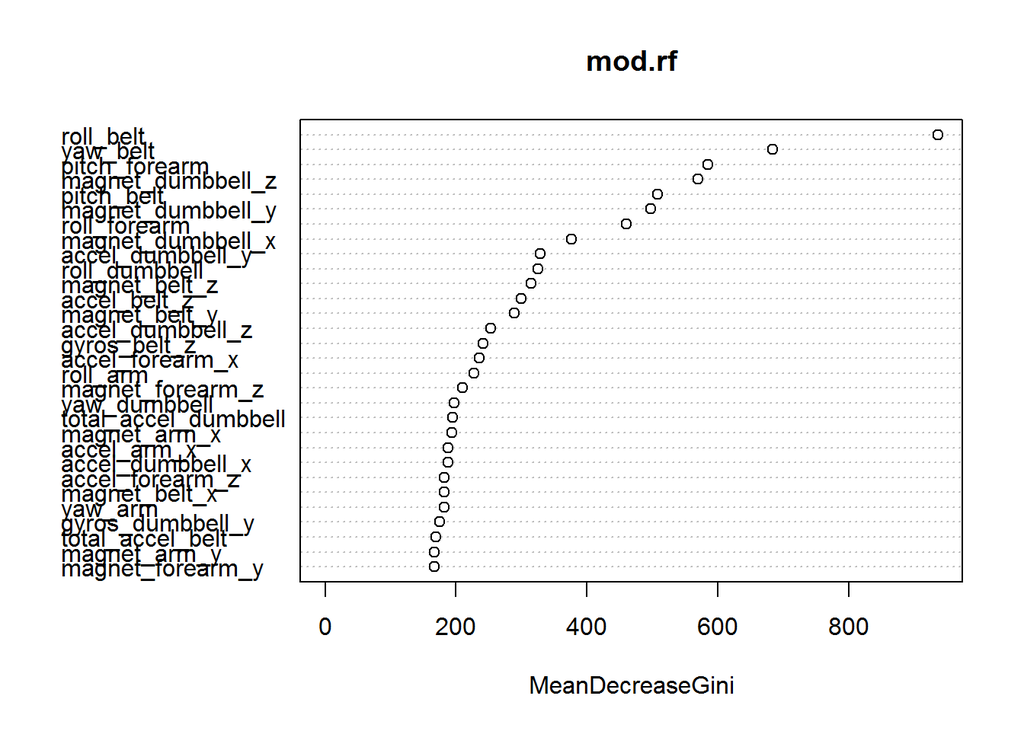

```r
varImpPlot(mod.rf)
```

As we can see, the most important data is produced by belt sensor and dumbbell sensors. Now, as we have a good model, we can try it on the unlabeled testing set.

```r
pred.rf.testing<-predict(mod.rf,testing)
pred.rf.testing
```

```
##  1  2  3  4  5  6  7  8  9 10 11 12 13 14 15 16 17 18 19 20
##  B  A  B  A  A  E  D  B  A  A  B  C  B  A  E  E  A  B  B  B
## Levels: A B C D E
```